# PGA EDA

Carter DeRosia

# 1. Examining the Data

### About the Dataset

This dataset was put together by Billy Kilduff in 2021. This data includes player statistics for each tournament from 2017 through 2020. You can find the raw dataset here: https://doi.org/10.5281/zenodo.5235684

### About the File

The csv file has 64 columns. I will describe the columns that are most relevant to my analysis.

1. `Player`: Name of golfer
2. `player id`: unique player ID
3. `tournament id`: unique tournament ID
4. `season`: year of season
5. `final position`: final position player ended up in
6. `major`: indicates if tournament is one of the 4 major tournaments (The Masters, PGA Championship, U.S. Open, The Open Championship)
7. `made cut`: indicates if the player made the cut (A typical pga tournament is 4 days long. After the second day the field of players is “cut” down to the top 55 or so players. A player only wins prize money if they make the cut)
8. `consecutive cuts made`: the number of consecutive cuts a player has coming into a tournament
9. `score`: players score relative to par (positive number means over par, negative means under par)
10. `sg_putt`: Strokes gained putting: measures how many strokes a player gained (or lost) on the green
11. `sg_arg`: Strokes gained around-the-green: measures how many strokes a player gained (or lost) on shots within 30 yards of the green, not including any shots on the green
12. `sg_app`: Strokes gained approach: measures how many strokes a player gained (or lost) on all shots that are not off from the tee on par-4 or par-5 holes and are not included in sg_arg or sg_putt. Tee shots on par-3 holes are included.
13. `sg_ott`: Strokes gained off the tee: measures how many strokes a player gained (or lost) on shots off the tee on all par-4 and par-5 holes.
14. `sg_t2g`: Strokes gained tee-to-green: measures how many strokes a player gained (or lost) on all shots taken by a player from the tee box to the green
15. `sg_total`: Strokes gained total: aggregate of all sg_statistics for a givevn tournament
16. `sg_stat_prev`: strokes gained for a respective measure in the previous tournament
17. `Drive Yards`: the average distance with a driver
18. `Fairways Hit`: percentage of fairways hit off the tee
19. `PUTTS/HOLE`: average number of putts per hole

### Importing Packages

```r
suppressPackageStartupMessages(library(tidyverse))
suppressPackageStartupMessages(library(corrplot))
```

### Loading Data

```r
pga <- read_csv("AnalysisFile.csv")
pga
```

```
## # A tibble: 14,041 × 64
##    player         `Height cm` `Weight lbs` DOB      Age `player id` date  course
##    <chr>                <dbl>        <dbl> <chr>  <dbl>       <dbl> <chr> <chr>
##  1 Robert Allenby         185          180 12/07…    46           5 29/1… Count…
##  2 Robert Allenby         185          180 12/07…    47           5 20/0… Trini…
##  3 Robert Allenby         185          180 12/07…    47           5 10/0… TPC S…
##  4 Robert Allenby         185          180 12/07…    47           5 15/0… TPC D…
##  5 Robert Allenby         185          180 12/07…    47           5 23/0… Keene…
##  6 Robert Allenby         185          180 12/07…    48           5 24/0… Coco …
##  7 Robert Allenby         185          180 12/07…    48           5 31/0… Coral…
##  8 Robert Allenby         185          180 12/07…    48           5 14/0… TPC D…
##  9 Robert Allenby         185          180 12/07…    48           5 21/0… Keene…
## 10 Robert Allenby         185          180 12/07…    48           5 22/0… Count…
## # ℹ 14,031 more rows
## # ℹ 56 more variables: `tournament name` <chr>, `tournament id` <dbl>,
## #   season <dbl>, `final position` <dbl>, major <dbl>, made_cut <dbl>,
## #   Consecutive_Cuts_Made <dbl>, Finish <dbl>, Score <dbl>, sg_putt <dbl>,
## #   sg_arg <dbl>, sg_app <dbl>, sg_ott <dbl>, sg_t2g <dbl>, sg_total <dbl>,
## #   sg_putt_prev <dbl>, sg_arg_prev <dbl>, sg_app_prev <dbl>,
## #   sg_ott_prev <dbl>, sg_t2g_prev <dbl>, sg_total_prev <dbl>, place <dbl>, …
```

# 2. Data Cleaning

```r
# standardizing date formats to yyyy-mm-dd
pga$DOB <- mdy(pga$DOB)
pga$date <- dmy(pga$date)

# replacing any 0 value in the `final position` column to be NA since 0th place does not make sense. Any 0 in this column means that the player either missed the cut, withdrew, or was disqualified so I will ignore those values.
pga$`final position`[pga$`final position` == 0] <- NA

# removing columns that I am not interested in digging deeper into
pga <- pga %>%
  select(-c(FariwaysGrass, GreensGrass, windspeedKmph, winddirDegree, visibility, tempC, pressure, precipMM, humidity, cloudcover, WindGustKmph, WindChillC, HeatIndexC, FeelsLikeC, DewPointC, sunset, sunrise, moonset, moonrise, moon_illumination, uvIndex, sunHour, totalSnow_cm, mintempC, maxtempC, Finish, place, course))



# adding a WIN column which indicates if a player won the tournament
pga <- pga %>%
  mutate(Win = if_else(`final position` == 1, 1, 0))

# adding a major_win column which indicates if a player won a tournament and that tournament was a major.
pga <- pga %>%
  mutate(major_win = if_else(Win == 1 & major == 1, 1, 0))

pga <- pga %>%
  distinct(player, date, `tournament name`, .keep_all = TRUE)
```

```r
pga
```

```
## # A tibble: 14,016 × 38
##    player       `Height cm` `Weight lbs` DOB          Age `player id` date
##    <chr>              <dbl>        <dbl> <date>     <dbl>       <dbl> <date>
##  1 Robert Alle…         185          180 1971-12-07    46           5 2017-10-29
##  2 Robert Alle…         185          180 1971-12-07    47           5 2018-05-20
##  3 Robert Alle…         185          180 1971-12-07    47           5 2018-06-10
##  4 Robert Alle…         185          180 1971-12-07    47           5 2018-07-15
##  5 Robert Alle…         185          180 1971-12-07    47           5 2018-07-23
##  6 Robert Alle…         185          180 1971-12-07    48           5 2019-02-24
##  7 Robert Alle…         185          180 1971-12-07    48           5 2019-03-31
##  8 Robert Alle…         185          180 1971-12-07    48           5 2019-07-14
##  9 Robert Alle…         185          180 1971-12-07    48           5 2019-07-21
## 10 Robert Alle…         185          180 1971-12-07    48           5 2019-09-22
## # ℹ 14,006 more rows
## # ℹ 31 more variables: `tournament name` <chr>, `tournament id` <dbl>,
## #   season <dbl>, `final position` <dbl>, major <dbl>, made_cut <dbl>,
## #   Consecutive_Cuts_Made <dbl>, Score <dbl>, sg_putt <dbl>, sg_arg <dbl>,
## #   sg_app <dbl>, sg_ott <dbl>, sg_t2g <dbl>, sg_total <dbl>,
## #   sg_putt_prev <dbl>, sg_arg_prev <dbl>, sg_app_prev <dbl>,
## #   sg_ott_prev <dbl>, sg_t2g_prev <dbl>, sg_total_prev <dbl>, …
```

# 3. EDA

A few questions would like to investigate

1. How does driving distance impact final position?
2. How does fairways hit impact final position?
3. How does putts/hole impact final position?
4. Who has won the most tournaments in this time period?
5. Who has won the most majors in this time period?
6. Who is the best at each part of the game? (ott, t2g, app, arg, putt)
7. Where are winners gaining the most strokes?
8. How does age impact driving distance, fairways hit, and putting?
9. Are players hitting the ball longer over time?
10. Correlation between all numeric parameters.

### 1. How does driving distance impact final position?

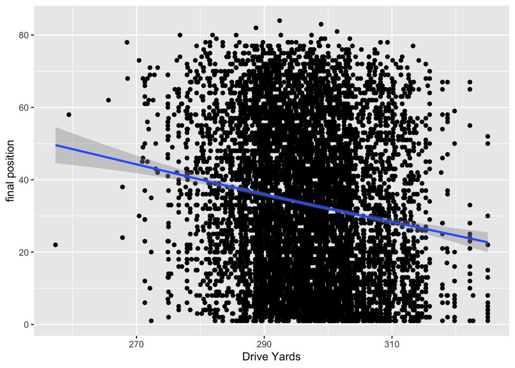

```r
pga %>%
  ggplot(aes(x = `Drive Yards`, y = `final position`)) + geom_point() + geom_smooth()
```

**We can see that generally, the farther a player hits the ball, the better final position they end up in.**

### 2. How does fairways hit impact final position?

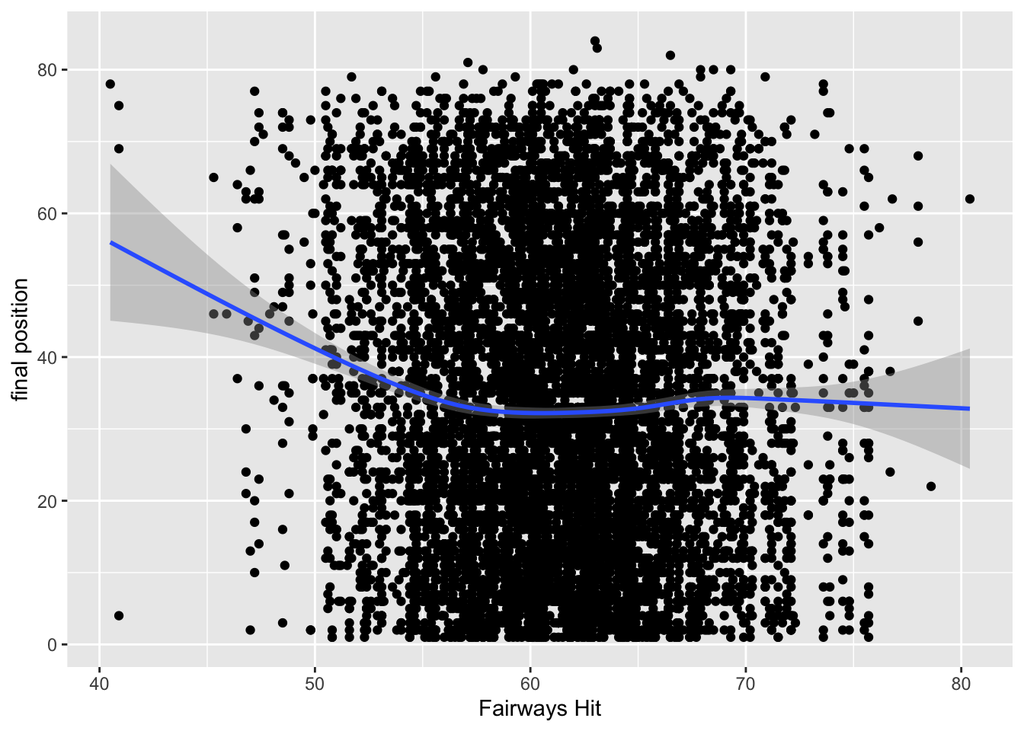

```r
pga %>%
  ggplot(aes(`Fairways Hit`, `final position`)) + geom_point() + geom_smooth()
```

**It appears that players who miss a lot of fairways (40% - 55% hit) struggle to place as well as those who hit more. However, we see that once you get past about 60% fairways hit, there’s no clear trend to say that the more fairways hit, the better you’ll place. In fact, it appears that those who hit 60% of fairways actually tend to place better than those who hit 70% of fairways which is an interesting finding. I am very interested as to why that is.**

### 3. How does putts/hole impact final position?

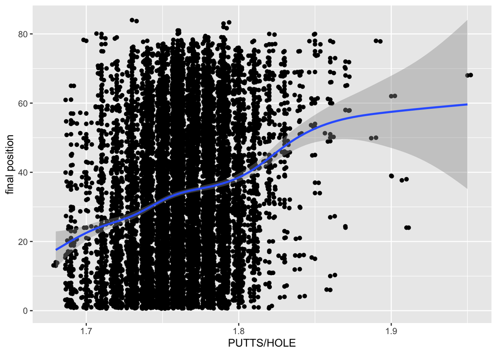

```r
pga %>%
  ggplot(aes(`PUTTS/HOLE`, `final position`)) + geom_point() + geom_jitter() + geom_smooth()
```

**The findings here are pretty close to what you would expect. Those who are taking less putts per hole are placing better than those who take more putts. This is quite trivial since the number of putts per hole is directly related to total number of strokes and the less strokes someone takes the better they will place.**

### 4. Who has won the most tournaments in this time period?

```r
pga %>%
  group_by(`player`) %>%
  summarize(number_of_wins = sum(Win, na.rm = TRUE)) %>%
  arrange(desc(number_of_wins))
```

```
## # A tibble: 321 × 2
##    player             number_of_wins
##    <chr>                       <dbl>
##  1 Dustin Johnson                  7
##  2 Justin Thomas                   7
##  3 Bryson DeChambeau               6
##  4 Brooks Koepka                   5
##  5 Rory McIlroy                    5
##  6 Jon Rahm                        4
##  7 Francesco Molinari              3
##  8 Justin Rose                     3
##  9 Patrick Cantlay                 3
## 10 Patrick Reed                    3
## # ℹ 311 more rows
```

**During this time period (2017-2020), Dustin Johnson and Justin Thomas are tied for the most wins with 7 each. Bryson DeChambeau is close behind them with 6 and Brooks Koepka and Rory McIlroy both have 5 wins each.**

### 5. Who has won the most majors in this time period?

```r
pga %>%
  group_by(player) %>%
  summarize(number_of_major_wins = sum(major_win, na.rm = TRUE)) %>%
  arrange(desc(number_of_major_wins))
```

```
## # A tibble: 321 × 2
##    player             number_of_major_wins
##    <chr>                             <dbl>
##  1 Brooks Koepka                         3
##  2 Bryson DeChambeau                     1
##  3 Collin Morikawa                       1
##  4 Francesco Molinari                    1
##  5 Gary Woodland                         1
##  6 Patrick Reed                          1
##  7 Shane Lowry                           1
##  8 Tiger Woods                           1
##  9 Aaron Baddeley                        0
## 10 Aaron Wise                            0
## # ℹ 311 more rows
```

**Brooks Koepka has the most major wins during this time period with 3. Bryson DeChambeau, Collin Morikawa, Francesco Molinari, Gary Woodland, Patrick Reed, Shane Lowry, and Tiger Woods all have 1 each.**

### 6. Who is the best at each part of the game? (ott, t2g, app, arg, putt)

```r
# removing any player who only played in one tournaments.
pga_filtered <- pga %>%
  group_by(player) %>%
  filter(n() > 1)


# finding the player who has the best average of strokes gained off the tee (sg_ott)
pga_filtered %>%
  group_by(player) %>%
  summarize(avg_sg_ott = mean(sg_ott, na.rm = TRUE)) %>%
  arrange(desc(avg_sg_ott))
```

```
## # A tibble: 319 × 2
##    player            avg_sg_ott
##    <chr>                  <dbl>
##  1 Rory McIlroy           0.84
##  2 Chan Kim               0.832
##  3 Jon Rahm               0.767
##  4 Dustin Johnson         0.743
##  5 Bubba Watson           0.723
##  6 Cameron Champ          0.670
##  7 Bryson DeChambeau      0.631
##  8 Viktor Hovland         0.628
##  9 Keith Mitchell         0.618
## 10 Scottie Scheffler      0.575
## # ℹ 309 more rows
```

```r
#finding the player who has the best average strokes gained tee to green (sg_t2g)
pga_filtered %>%
  group_by(player) %>%
  summarize(avg_sg_t2g = mean(sg_t2g, na.rm = TRUE)) %>%
  arrange(desc(avg_sg_t2g))
```

```
## # A tibble: 319 × 2
##    player           avg_sg_t2g
##    <chr>                 <dbl>
##  1 Justin Thomas         1.63
##  2 Rory McIlroy          1.52
##  3 Patrick Cantlay       1.29
##  4 Hideki Matsuyama      1.25
##  5 Adam Scott            1.21
##  6 Dustin Johnson        1.21
##  7 Jon Rahm              1.18
##  8 Collin Morikawa       1.17
##  9 Tony Finau            1.00
## 10 Viktor Hovland        0.991
## # ℹ 309 more rows
```

```r
#finding the player who has the best average strokes gained approach (sg_app)
pga_filtered %>%
  group_by(player) %>%
  summarize(avg_sg_app = mean(sg_app, na.rm = TRUE)) %>%
  arrange(desc(avg_sg_app))
```

```
## # A tibble: 319 × 2
##    player           avg_sg_app
##    <chr>                 <dbl>
##  1 Henrik Stenson        0.96
##  2 Justin Thomas         0.870
##  3 Collin Morikawa       0.771
##  4 Viktor Hovland        0.689
##  5 Adam Scott            0.683
##  6 Hideki Matsuyama      0.644
##  7 Tiger Woods           0.633
##  8 Paul Casey            0.624
##  9 Emiliano Grillo       0.614
## 10 Keegan Bradley        0.612
## # ℹ 309 more rows
```

```r
#finding the player who has the best average strokes gained around the green (sg_arg)
pga_filtered %>%
  group_by(player) %>%
  summarize(avg_sg_arg = mean(sg_arg, na.rm = TRUE)) %>%
  arrange(desc(avg_sg_arg))
```

```
## # A tibble: 319 × 2
##    player          avg_sg_arg
##    <chr>                <dbl>
##  1 Daniel Chopra        0.533
##  2 Aaron Baddeley       0.474
##  3 Jerry Kelly          0.467
##  4 Steve Stricker       0.461
##  5 Bernhard Langer      0.425
##  6 Mike Weir            0.417
##  7 Luke Donald          0.414
##  8 Brandt Snedeker      0.387
##  9 Byeong Hun An        0.384
## 10 Jason Bohn           0.352
## # ℹ 309 more rows
```

```r
#finding the player who has the best average strokes gained around the green (sg_putt)
pga_filtered %>%
  group_by(player) %>%
  summarize(avg_sg_putt = mean(sg_putt, na.rm = TRUE)) %>%
  arrange(desc(avg_sg_putt))
```

```
## # A tibble: 319 × 2
##    player             avg_sg_putt
##    <chr>                    <dbl>
##  1 Denny McCarthy           0.678
##  2 Daniel Summerhays        0.665
##  3 Kristoffer Ventura       0.628
##  4 Webb Simpson             0.534
##  5 Brendon Todd             0.504
##  6 Wyndham Clark            0.501
##  7 Maverick McNealy         0.486
##  8 Dominic Bozzelli         0.457
##  9 Peter Malnati            0.439
## 10 Patrick Rodgers          0.438
## # ℹ 309 more rows
```

**We can see that during this time period, the following players lead their respective strokes gained statistic:**

- SG_OTT: Rory McIlroy (0.84)
- SG_T2G: Justin Thomas (1.627)
- SG_APP: Henrik Stenson (0.96)
- SG_ARG: Daniel Chopra (0.533)
- SG_PUTT: Denny McCarthy (0.678)

### 7. Where are winners gaining the most strokes?

```r
pga %>%
  group_by(Win) %>%
  summarize(mean_sg_ott = mean(sg_ott, na.rm = TRUE), mean_sg_app = mean(sg_app, na.rm = TRUE), mean_sg_arg = mean(sg_arg, na.rm = TRUE), mean_sg_putt = mean(sg_putt, na.rm = TRUE))
```

```
## # A tibble: 3 × 5
##     Win mean_sg_ott mean_sg_app mean_sg_arg mean_sg_putt
##   <dbl>       <dbl>       <dbl>       <dbl>        <dbl>
## 1     0       0.131       0.255       0.108        0.241
## 2     1       0.725       1.34        0.371        1.28
## 3    NA      -0.273      -0.555      -0.226       -0.604
```

**From this table, we can see a few things. First off, winners typically gain 0.59 strokes of the tee, 1.088 strokes on approach shots, 0.262 strokes around the green, and 1.04 strokes putting. This provides some very interesting results. Golfers who are winning tournaments are gaining the most strokes on their approach shots and putting. There is still a clear increase in strokes gained off the tee for winners vs non winners but the difference is only about half as much as off the tee and putting. When looking at strokes gained around the green we see there is only a relatively small difference between winners and losers. This shows that the average PGA Tour player should focus on approach shots and putting in order to have better chance at winning tournaments.**

### 8. How does age impact driving distance, fairways hit, and putting?

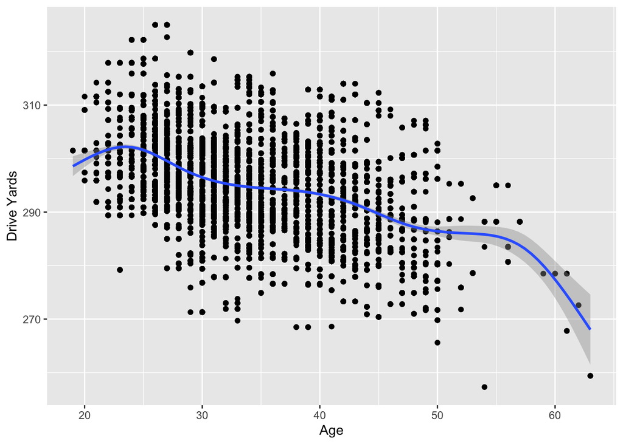

```r
pga %>%
  ggplot(aes(Age, `Drive Yards`)) + geom_point() + geom_smooth()
```

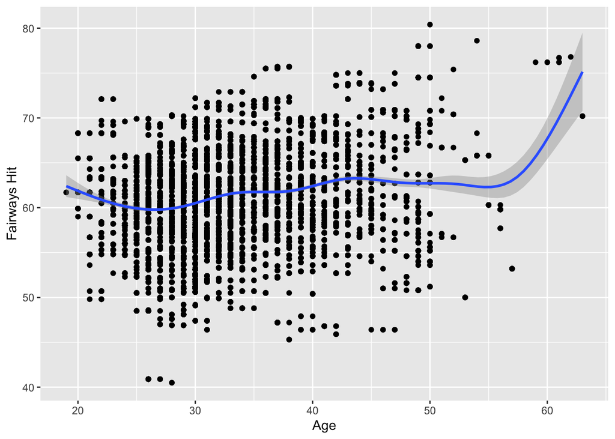

```r
pga %>%
  ggplot(aes(Age, `Fairways Hit`)) + geom_point() + geom_smooth()
```

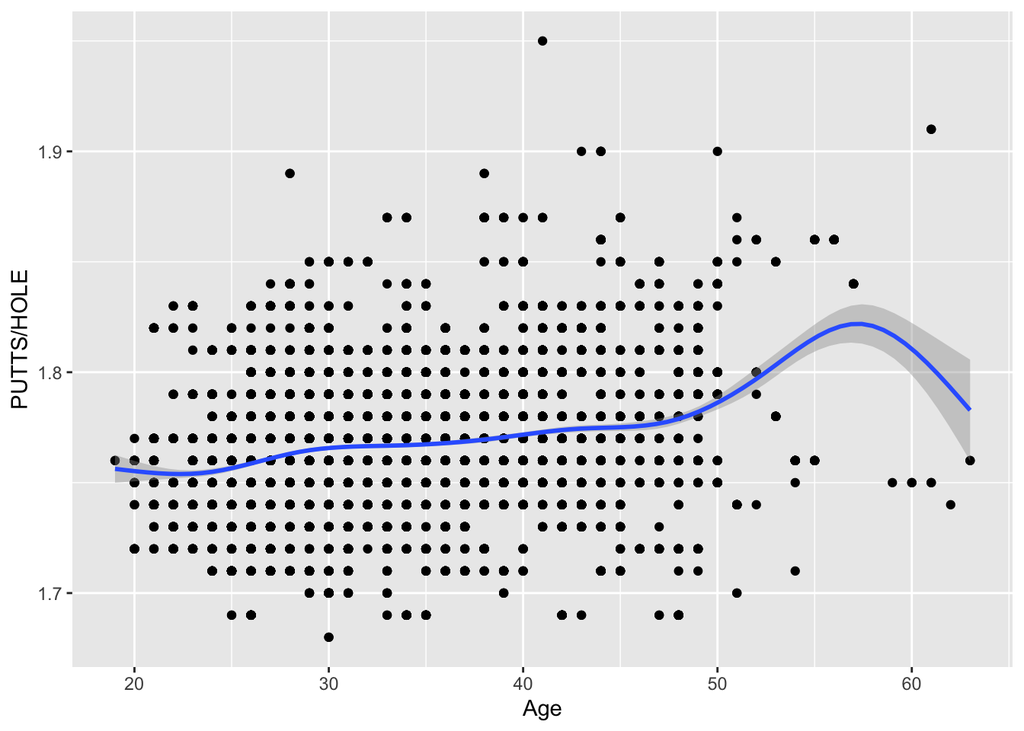

```r
pga %>%
  ggplot(aes(Age, `PUTTS/HOLE`)) + geom_point() + geom_smooth()
```

**It looks like the older a player is, they tend to hit it shorter than those younger than them. For fairway hit percentage, it seems to stay pretty constant across the ages until we get to about 55, where we see a big increase in fairway hit percentage. For number of putts per hole we see that there is a slight increase as age increases until about 55 again where there is a large decrease.**

### 9. Are players hitting the ball longer over time?

```r
avg_drive_pga <- pga %>%
  mutate(year = year(date)) %>%
  group_by(year) %>%
  summarize(avg_drive_distance = mean(`Drive Yards`, na.rm = TRUE))
avg_drive_pga
```

```
## # A tibble: 5 × 2
##    year avg_drive_distance
##   <dbl>              <dbl>
## 1  2017               296.
## 2  2018               296.
## 3  2019               295.
## 4  2020               296.
## 5    NA               NaN
```

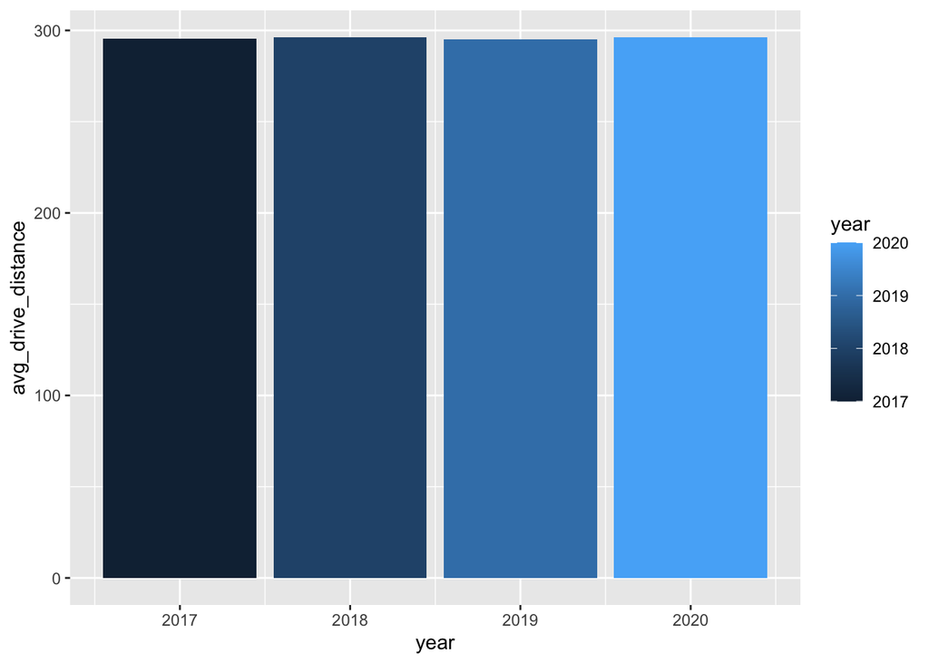

```r
avg_drive_pga %>%
  ggplot(aes(year, avg_drive_distance, fill = year)) + geom_col()
```

**From both the histogram and the table it appears that there is not a clear trend to suggest an increase in driving distance over time. There is about a 0.5 yard increase between 2017 and 2018. Then between 2018 and 2019 we see about a 1.2 yard decrease. Lastly, between 2019 and 2020 we see about a 1.4 yard increase. From this data it is hard to say if players are getting longer year after year. It would make more sense to look at this question over a longer period of time to determine this.**

### 10. Correlation between all numeric parameters.

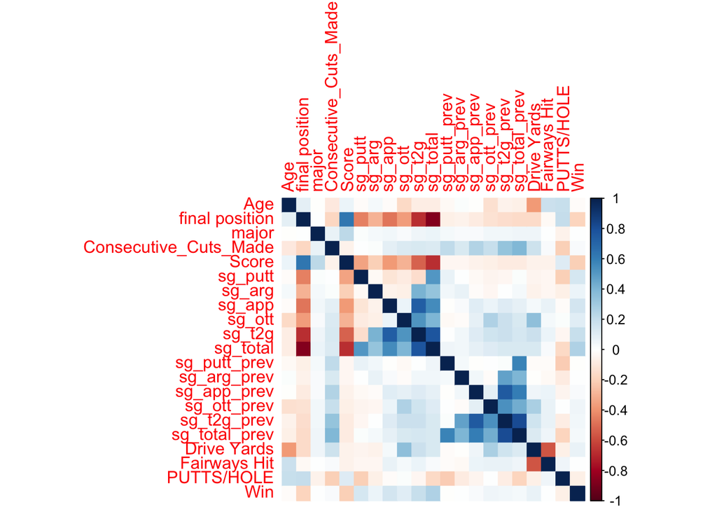

```r
pga_heatmap <- pga %>%
  select(Age, `final position`, major, `Consecutive_Cuts_Made`, Score, sg_putt, sg_arg, sg_app, sg_ott, sg_t2g, sg_total, sg_putt_prev, sg_arg_prev, sg_app_prev, sg_ott_prev, sg_t2g_prev, sg_total_prev, `Drive Yards`, `Fairways Hit`, `PUTTS/HOLE`, Win )

pga_heatmap <- na.omit(pga_heatmap)
corr <- cor(pga_heatmap)
corrplot(corr, method = "color")
```